# Premier League Season Forecast

## Executive summary

Title favourite

Arsenal

51.9% · next Man City 32.5%

Top-4 near-certain (≥90%)

Arsenal, Man City

Relegation favourite

Coventry

93.0% · 5 teams ≥20%

Season progress

40 / 380

340 fixtures remaining

Simulations

10,000

500 rating draws

Model

Home adv ×1.18

ρ = -0.124 · 410 effective matches

⚠ Low-data teams: Hull, Coventry. Their ratings rest on fewer than 10 effective matches, so their tail probabilities (title, relegation) are wide and will tighten as the season progresses.

## Season forecast

Expected points with a 90% interval (5th–95th percentile across simulated seasons). Probabilities are the share of simulated seasons in which each outcome occurred.

| Team | P | Pts | Exp. pts | 90% interval | Exp. pos | Title | Top 4 | Top 6 | Relegation | Eff. matches |
| --- | --- | --- | --- | --- | --- | --- | --- | --- | --- | --- |
| Arsenal | 4 | 12 | 80.3 | 66 – 94 | 1.9 | 51.9% | 95.8% | 98.8% | 0.0% | 41 |
| Man City | 4 | 12 | 76.8 | 62 – 91 | 2.4 | 32.5% | 91.0% | 97.1% | 0.0% | 41 |
| Liverpool | 4 | 6 | 60.6 | 45 – 75 | 6.7 | 1.7% | 34.8% | 55.7% | 0.6% | 41 |
| Hull ⚠ | 4 | 8 | 60.6 | 35 – 87 | 7.6 | 9.4% | 39.4% | 52.2% | 6.0% | 4 |
| Chelsea | 4 | 7 | 58.5 | 44 – 74 | 7.6 | 1.1% | 24.7% | 45.5% | 0.8% | 41 |
| Brighton | 4 | 7 | 57.7 | 43 – 73 | 7.9 | 1.0% | 23.3% | 43.0% | 0.9% | 41 |
| Brentford | 4 | 6 | 55.2 | 40 – 70 | 9.0 | 0.4% | 15.7% | 33.1% | 2.0% | 41 |
| Leeds | 4 | 8 | 55.4 | 39 – 72 | 9.0 | 0.8% | 17.9% | 33.5% | 2.4% | 28 |
| Man United | 4 | 4 | 54.4 | 39 – 70 | 9.4 | 0.4% | 13.9% | 29.0% | 2.4% | 41 |
| Newcastle | 4 | 5 | 52.8 | 38 – 68 | 10.1 | 0.3% | 9.2% | 22.4% | 3.0% | 41 |
| Nott'm Forest | 4 | 5 | 52.7 | 38 – 67 | 10.1 | 0.2% | 8.9% | 22.4% | 3.4% | 41 |
| Bournemouth | 4 | 3 | 52.6 | 38 – 67 | 10.1 | 0.1% | 9.8% | 22.6% | 3.2% | 41 |
| Everton | 4 | 6 | 50.6 | 36 – 66 | 11.1 | 0.1% | 6.1% | 16.0% | 5.2% | 41 |
| Aston Villa | 4 | 1 | 48.8 | 34 – 64 | 11.9 | 0.1% | 4.5% | 12.3% | 8.1% | 41 |
| Sunderland | 4 | 4 | 45.1 | 30 – 61 | 13.5 | 0.0% | 2.2% | 6.6% | 16.0% | 28 |
| Fulham | 4 | 1 | 42.7 | 28 – 58 | 14.4 | 0.0% | 1.2% | 3.7% | 22.2% | 41 |
| Crystal Palace | 4 | 3 | 42.0 | 27 – 57 | 14.7 | 0.0% | 0.9% | 3.3% | 26.0% | 41 |
| Tottenham | 4 | 2 | 40.6 | 27 – 55 | 15.3 | 0.0% | 0.4% | 1.9% | 30.8% | 41 |
| Ipswich | 4 | 6 | 31.3 | 18 – 47 | 17.9 | 0.0% | 0.1% | 0.4% | 74.2% | 17 |
| Coventry ⚠ | 4 | 0 | 17.8 | 4 – 39 | 19.4 | 0.0% | 0.1% | 0.4% | 93.0% | 4 |

Blue line: Champions League places. Red line: relegation zone. ⚠ marks low-data teams.

## Upcoming fixtures

Model probabilities for the next round. Market = de-vigged Bet365 pre-match odds, for comparison. Expected goals are λ (home) and μ (away).

| Date | Fixture | xG (H–A) | Home | Draw | Away | Likely score | Mkt H | Mkt D | Mkt A |
| --- | --- | --- | --- | --- | --- | --- | --- | --- | --- |
| Fri 18 Sep | Brentford v Chelsea | 1.68 – 1.48 | 41% | 26% | 33% | 1–1 | 37% | 25% | 38% |
| Sat 19 Sep | Tottenham v Aston Villa | 1.28 – 1.43 | 32% | 29% | 39% | 1–1 | 47% | 27% | 26% |
| Sat 19 Sep | Brighton v Arsenal | 0.96 – 1.56 | 22% | 28% | 50% | 1–1 | 19% | 24% | 57% |
| Sat 19 Sep | Everton v Ipswich | 2.04 – 0.88 | 63% | 23% | 14% | 2–0 | 54% | 25% | 21% |
| Sat 19 Sep | Newcastle v Hull | 0.97 – 1.09 | 30% | 34% | 36% | 1–1 | 59% | 22% | 19% |
| Sat 19 Sep | Nott’m Forest v Coventry | 2.01 – 0.42 | 75% | 20% | 6% | 2–0 | 60% | 24% | 16% |
| Sun 20 Sep | Bournemouth v Liverpool | 1.53 – 1.58 | 36% | 26% | 38% | 1–1 | 30% | 25% | 45% |
| Sun 20 Sep | Leeds v Crystal Palace | 1.60 – 1.05 | 49% | 28% | 23% | 1–1 | 55% | 25% | 20% |
| Sun 20 Sep | Man City v Sunderland | 1.84 – 0.69 | 64% | 24% | 12% | 2–0 | 72% | 17% | 10% |
| Sun 20 Sep | Fulham v Man United | 1.32 – 1.44 | 33% | 28% | 38% | 1–1 | 27% | 25% | 48% |

## Final-position probabilities

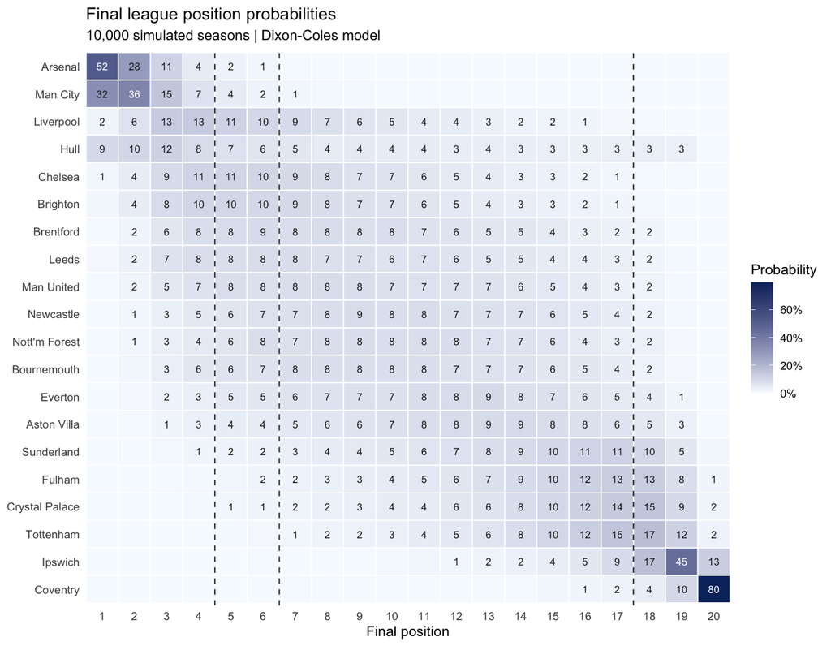

## Points distributions

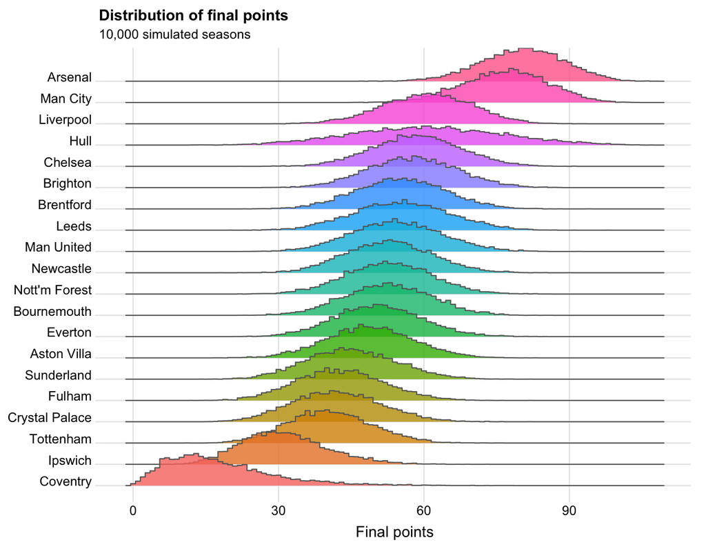

## Title race and relegation

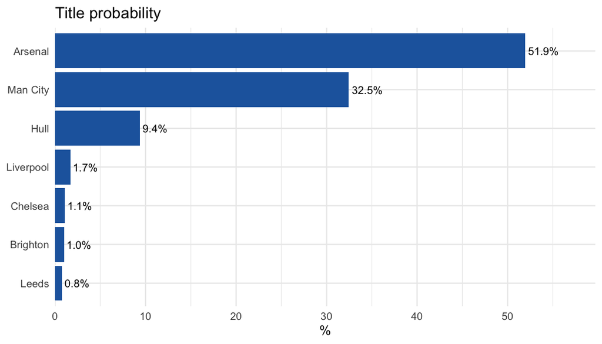

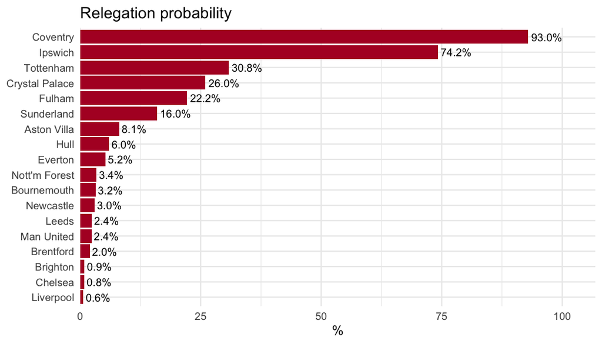

## Team ratings

Attack and defence are multipliers on the league-average goal rate (defence below 1 = concedes fewer than average). Standard deviations are from the fitted model’s approximate posterior; large values mean the rating is still uncertain.

| Team | Attack | Defence | Net rating | Eff. matches |
| --- | --- | --- | --- | --- |
| Arsenal | 1.41 ± 0.12 | 0.63 ± 0.18 | +0.81 | 41 |
| Man City | 1.51 ± 0.11 | 0.80 ± 0.16 | +0.64 | 41 |
| Hull | 0.92 ± 0.38 | 0.66 ± 0.46 | +0.33 | 4 |
| Liverpool | 1.42 ± 0.12 | 1.07 ± 0.14 | +0.29 | 41 |
| Brighton | 1.29 ± 0.12 | 1.11 ± 0.14 | +0.15 | 41 |
| Chelsea | 1.31 ± 0.12 | 1.15 ± 0.14 | +0.13 | 41 |
| Man United | 1.27 ± 0.12 | 1.13 ± 0.14 | +0.11 | 41 |
| Brentford | 1.24 ± 0.13 | 1.13 ± 0.14 | +0.09 | 41 |
| Bournemouth | 1.21 ± 0.13 | 1.11 ± 0.14 | +0.09 | 41 |
| Newcastle | 1.24 ± 0.13 | 1.19 ± 0.13 | +0.04 | 41 |
| Nott'm Forest | 1.06 ± 0.13 | 1.02 ± 0.14 | +0.04 | 41 |
| Leeds | 1.10 ± 0.16 | 1.08 ± 0.16 | +0.02 | 28 |
| Aston Villa | 1.12 ± 0.13 | 1.10 ± 0.14 | +0.02 | 41 |
| Everton | 0.95 ± 0.14 | 1.00 ± 0.14 | -0.04 | 41 |
| Fulham | 0.99 ± 0.14 | 1.13 ± 0.14 | -0.13 | 41 |
| Sunderland | 0.86 ± 0.17 | 1.03 ± 0.17 | -0.18 | 28 |
| Crystal Palace | 0.97 ± 0.14 | 1.24 ± 0.13 | -0.24 | 41 |
| Tottenham | 0.98 ± 0.14 | 1.28 ± 0.13 | -0.26 | 41 |
| Ipswich | 0.89 ± 0.21 | 1.81 ± 0.17 | -0.71 | 17 |
| Coventry | 0.41 ± 0.52 | 1.60 ± 0.31 | -1.37 | 4 |

## Model validation

Rolling-origin backtest on the two previous seasons: each week’s matches were forecast from a model fitted only on earlier data, and scored against the actual result. Lower log-loss is better; the bookmaker row is the de-vigged closing line.

| Model | Matches | Log-loss | Brier | vs market |
| --- | --- | --- | --- | --- |
| Bookmaker (de-vigged closing) | 750 | 0.9933 | 0.5943 | +0.0000 |
| DC xi=0.0018 ridge=1 prior=0 | 750 | 1.0024 | 0.6005 | +0.0091 |
| DC xi=0.0018 ridge=1 prior=10 | 750 | 1.0036 | 0.6012 | +0.0103 |
| DC xi=0.0018 ridge=1 prior=20 | 750 | 1.0069 | 0.6036 | +0.0136 |
| DC xi=0.0018 ridge=1 prior=40 | 750 | 1.0169 | 0.6105 | +0.0236 |
| Naive base rates | 750 | 1.0855 | 0.6577 | +0.0922 |

## Methodology

- **Goal model:** Dixon-Coles (1997) bivariate Poisson with a low-score dependence correction (ρ). Each team has an attack and a defence rating; home advantage is a fitted parameter.
- **Recent form:** matches are weighted by exp(−ξ × days ago), ξ = 0.0018 per day, so a result loses half its weight after about 13 months.
- **Simulation:** every remaining fixture is sampled from the exact score-probability matrix. 10,000 seasons were simulated under 500 rating vectors drawn from the model’s approximate posterior, so teams with little data carry wider uncertainty.
- **Tie-breaks:** points, then goal difference, then goals scored.
- **Data:** football-data.co.uk results, seasons 2425, 2526, 2627.